# App-2) Text Analysis of Harry Potter Books

Stat 133, Fall 2024

Author

Gaston Sanchez

# About

In this assignment, you will build a shiny app to visualize the results from a text analysis performed on the seven *Harry Potter*[^1] books written by Joanne Kathleen Rowling:

1. Harry Potter and the Philosopher’s Stone
2. Harry Potter and the Chamber of Secrets
3. Harry Potter and the Prisoner of Azkaban
4. Harry Potter and the Goblet of Fire
5. Harry Potter and the Order of the Phoenix
6. Harry Potter and the Half-Blood Prince
7. Harry Potter and the Deathly Hallows

**Important Note**

We are assuming that you have reviewed the learning materials of weeks 8, 9, and 10. Specifically, we are assuming that you have reviewed the text-mining readings from *Text Mining with R* (by Julia Silge and David Robinson):

https://www.tidytextmining.com/tidytext

https://www.tidytextmining.com/ngrams

https://www.tidytextmining.com/sentiment

# 1 Data

**About**

This section introduces the data for this assignment.

The data for this assignment involves the text of Harry Potter books. This data is available in two different presentations:

1. A single `csv` file (with the text of all seven Harry Potter books)
2. A set of seven `rda`[^2] files (one file per book)

All these files are located in the `app2/` folder (see bCourses folder `Files/hws/app2`).

**In case of trouble …**

For sake of redundancy (in case you experience any issue when trying to access the files through bCourses), you can also find the associated files in the following github repository:

https://github.com/gastonstat/harry-potter-data

## 1.1 Single `CSV` file `harry_potter_books.csv`

The data of all the books is available in `CSV` format. You may want to use this file to perform sentiment analysis, or word-trend analysis.

```r
# assuming that the csv file is in your working directory
hp_books = read_csv("harry_potter_books.csv", col_types = "ccc")
```

This data set is fairly simple—in terms of its structure—although the text content is far from being tidy. The dataset has 95,085 rows and 3 columns:

1. `text`: text content
2. `book`: title of associated book
3. `chapter`: associated chapter number

## 1.2 Seven `rda` files

The data of each book is also available in its own R-Data `rda`[^3] file. To be more precise, **the text of each book comes in a character vector** with as many elements as chapters in a book.

You may want to use these files to perform bigram analysis (or other type of n-gram analysis).

To import these files use the `load()` function:

```r
# assuming that the rda files are in your working directory
load("philosophers_stone.rda")
load("chamber_of_secrets.rda")
load("prisoner_of_azkaban.rda")
load("goblet_of_fire.rda")
load("order_of_the_phoenix.rda")
load("half_blood_prince.rda")
load("deathly_hallows.rda")
```

Consider the first book “Harry Potter and the Philosopher’s Stone”. Assuming that you’ve loaded the file `"philosophers_stone.rda"`, the text of this book is available in the homonym character vector `philosophers_stone`

```r
# length correspond to number of chapters
length(philosophers_stone)
```

```
[1] 17
```

As mentioned before, the number of elements in `philosophers_stone` corresponds to the number of chapters in this book: 17 chapters.

# 2 Text Analysis

**About**

This section provides some of the suggested text analysis that you can perform for this assignment.

Listed below are some text analysis ideas for you to get inspiration from. We are also including recommended readings (some available in bCourses, some available in the book “Text Mining with R”, by Silge & Robinson).

**Important note**

Out of the five listed types of text analysis (2.1-2.5) you will have to choose two of them in order to create the shiny app

## 2.1 Sentiment Analysis

Perhaps the broader and richer type of analysis that can be performed on the Harry Potter text data involves sentiment analysis. Given the amount of text—spread across the seven books and all their chapters—and the four sentiment lexicons (`bing`, `afinn`, `nrc`, `loughran`), the options to do all sorts of sentiment analysis seem limitless.

For example, here are a few ideas (this is by no means an exhaustive list):

- Given a certain book, compute sentiment scores and visualize them across a plot trajectory. This is what Julia Silge refers to as the “track of narrative time in sections of text”. To clarify, the notion of *section of text* does not necessarily have to match an entire chapter.
- Compute a sentiment score for each chapter or book. And then rank them from more positive to more negative (or viceversa). Again, note that different scores can be obtained by using different lexicons. Which chapters or books have “relatively large” positive or negative scores? And/or what words contribute the most for the score?

### 2.1.1 Sentiment Lexicons Files

For the sake of convenience, you can find `CSV` files of all the sentiment lexicons in the bCourses folder `hws/app2/sentiment-lexicons`

https://bcourses.berkeley.edu/courses/1536526/files/folder/hws/app2/sentiment-lexicons

**In case of trouble …**

If you experience any access issue through bCourses (hopefully not), you can also find the associated files in the following github repository:

https://github.com/gastonstat/harry-potter-data/sentiment-lexicons

```r
# assuming that the CSV files are in your working directory
bing = read_csv("bing.csv")
afinn = read_csv("afinn.csv")
nrc = read_csv("nrc.csv")
loughran = read_csv("loughran.csv")
```

Assuming that you’ve loaded the file `"bing.csv"`, the associated lexicon is available in the homonym tibble `bing`

```r
bing
```

```
# A tibble: 6,786 × 2
   word        sentiment
   <chr>       <chr>
 1 2-faces     negative
 2 abnormal    negative
 3 abolish     negative
 4 abominable  negative
 5 abominably  negative
 6 abominate   negative
 7 abomination negative
 8 abort       negative
 9 aborted     negative
10 aborts      negative
# ℹ 6,776 more rows
```

**Suggested reading**

- `tutorial-tm1-sentiment-analysis.html` (see `Files/hws/app2/tutorials` in bCourses)

  https://bcourses.berkeley.edu/courses/1536526/files/folder/hws/app2/tutorials
- See also chapter 2 “Sentiment analysis with tidy data” (in “Text Mining with R”; link below)

  https://www.tidytextmining.com/sentiment

## 2.2 Word Trend Analysis

Another possibility consists of a **word trend** analysis.

One example of words could be the names of main characters: `"harry"`, `"ron"`, `"hermione"`, `"dumbledore"`, `"voldemort"`, `"hagrid"`, etc. Here is one of many websites that contain a list of main characters: https://www.hp-lexicon.org/characters/

With these names, one can compute their relative frequencies (i.e. proportion of occurrences) across the books, and visualize their trend. See the tutorial listed below to get a better idea of this kind of trend.

Alternatively, you can also look for one or more specific words, and see how they are used across chapters of a book, or across the seven books. For instance, how does the word `"love"` is used across the chapters of the first book “The Philosopher’s Stone”? Or other words such as `"spell"`, `"potion"`, `"wand"`, `"quidditch"`, to mention but a few.

**Suggested reading**

- `tutorial-tm2-word-trend-analysis.html` (see `Files/hws/app2/tutorials` in bCourses)

  https://bcourses.berkeley.edu/courses/1536526/files/folder/hws/app2/tutorials
- See figure 5.4 in “Text Mining with R” (link below) to get a rough idea about this type of trends over time. Obviously there is no time in Harry Potter but you can use the sequence of chapters as a proxy of time.

  https://www.tidytextmining.com/dtm.html#tidying-dfm-objects

## 2.3 Word and Document Frequency (tf-idf)

You can also look at a term’s inverse document frequency (idf), which decreases the weight for commonly used words and increases the weight for words that are not used very much in a collection of documents. This can be combined with term frequency to calculate a **term’s tf-idf** (the two quantities multiplied together), the frequency of a term adjusted for how rarely it is used.

**Suggested reading**

- See chapter 3 “Analyzing word and document frequency: tf-idf” (in “Text Mining with R”; link below)

  https://www.tidytextmining.com/tfidf

## 2.4 Bigram Analysis

Another type of analysis involves studying so-called **bigrams** (or n-grams in general) for answering questions like:

- what kind of words tend to be associated with other words?

**Suggested reading**

- See chapter 4 “Relationships between words: n-grams and correlations” (in “Text Mining with R”; link below)

  https://www.tidytextmining.com/ngrams

**Warning**: visualizing graph networks of n-grams tends to be computationally expensive due to the size of the text data.

## 2.5 Correspondence Analysis

Lastly, another analysis idea that you can explore is to apply Correspondence Analysis (CA) to study how documents are associated to certain words or tokens. You could actually do a mix of sentiment analysis with correspondence analysis, like in the example we discussed in class (10/30 & 11/01). Likewise, you can also explore how certain characters use certain tokens.

**Suggested reading**

- See notes about Correspondence Analysis (in the course website)

  https://stat133.berkeley.edu/fall-2024/docs/tm-correspondence/text-mining-corresp-analysis2.html

# 3 Shiny App

**About**

This section describes generic specifications of the shiny app.

The main data product to be delivered for this assignment is a shiny app that allows the user to explore the results of two types of text analysis.

Keep in mind that even if two (or more) students choose to work on the same type of analyses, there is still enough room to approach them in slightly different ways, therefore producing different shiny apps, with different scopes, and of course different data visualizations and outputs.

**Important Note**

It is possible to find—online—various types of text analysis on Harry Potter data that different authors/analysts have performed in the past. You can definitely get inspiration from them, but we expect that you do your own work, write your own code, and conduct yourself with academic integrity.

### Demo App

For sake of illustration, I’ve created a sample shiny app `app-demo.R` that you can find in bCourses, see folder `hws/app2/app-demo.R`:

https://bcourses.berkeley.edu/courses/1536526/files/folder/hws/app2?preview=89803486

This app is just for demo purposes, and it contains a simplistic word frequency analysis, and also a minimal sentiment analysis. 🚫 **You are NOT allowed to use these analyses in your app**! 🚫

## 3.1 Template App

In addition to the demo app, you can also find a template R script file `app-template.R` in bCourses, see folder `Files/hws/app2`.

### Layout

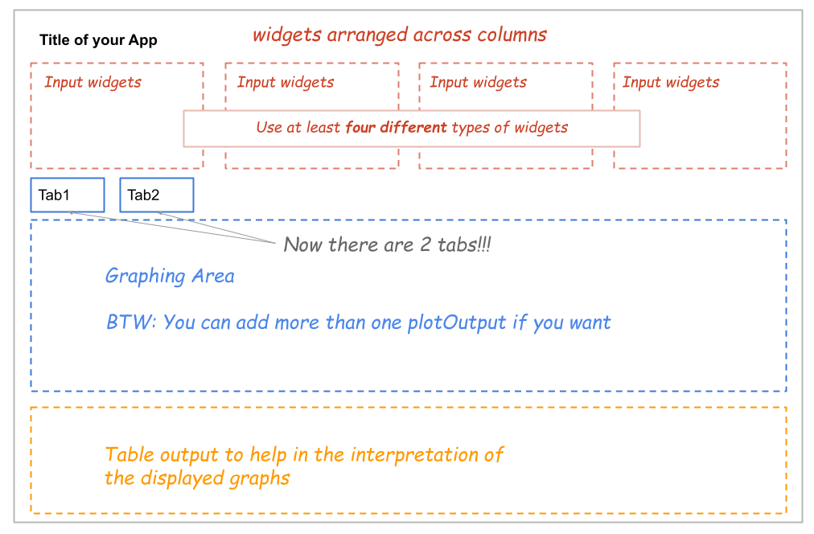

Figure 1: Diagram of the overall shiny app’s layout

As you can tell from the above diagram, the layout of the app is different to the shiny app-1.

One big difference in the app for this assignment is in the fact that it uses **two tabs**:

1. **Analysis1**: this tab is for displaying the results for one type of text analysis (for example: sentiment analysis)
2. **Analysis2**: this tab is for displaying the results for another type of text analysis (for example: word trend analysis)

Another big difference is that input widgets are arranged across 4 columns:

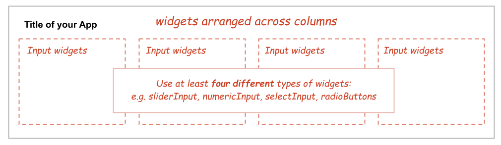

Figure 2: Input widgets arranged across columns

## 3.2 Specs

From the diagram in figure 1, note that there are four distinctive sections in the layout—see template file `app-template.R`:

- **title**: Main title for your app (give it a meaningful name).
- **input widgets**: The template already contains various input widgets arranged in four columns. You can change this configuration if you want, as well as the types and number of widgets. The only condition is to use at least four **different** types of widgets (e.g. slider, numeric, text, and select).
- **tab-1:**: The first tab involves one kind of text analysis. In turn, there is a graphic area, and a table area.
- **tab-2:**: Like tab-2, the second tab is for another kind of text analysis. It also has a graphic area, and a table area.

# 4 Submission

Like in app1, your submission should include the following:

- 📄 R File
- 🔗 Link to published app
- 🎬 Link to video

## 4.1 📄 R File

You will have to submit—to bCourses—the `app.R` file (do NOT confuse with a `qmd` file) containing the code of your app.

## 4.2 🔗 Link to published app

You will also have to submit the link to your published app in [shinyapps.io](https://www.shinyapps.io/) (the free version). Share the link with us in the comments section of the submission in bCourses.

## 4.3 🎬 Link to Video

In addition to the `app.R` file, you will also have to record a video—maximum length of 3:30 minutes—with both **screen and face** capture, in which you show us your published shiny app, how to use it, and a description of the produced visualizations. Share the **public link** with us in the comments section of the submission in bCourses.

Regardless of where you decide to host the file of your video, you must share the **public link** (don’t make it private) in bCourses: use the “comments section” of the submission to add this link as a comment. To be clear: do NOT upload the video to bCourses, just its link.

Make sure that the video does not exceed 3-min and 30-sec, that its resolution is okay, without too much background noise, avoid very low volume or inaudible audio, and also ensure that your image is stable (don’t make us watch a shaky video).

## Rubric

Roughly speaking, the code of the app (app.R) is worth about 70%, the video is worth about 20%, and the published app (shinyapps.io) is about 10%.

**0 pts:**

- Didn’t attempt or very very wrong/poor.

**1-2 pts:**

- Got started and made initial progress, but went off in the wrong direction or with no clear direction. And/or mostly incomplete.

**3-4 pts:**

- Got started and made some progress, but submission elements are highly incomplete or have major/fatal issues.

**5 pts:**

- Somewhat in the right direction and got half-way there.
- All elements (app.R, shinyapps.io, video) are submitted; app has major/fatal issues.
- shinyapps.io AND video missing or not working (app.R submitted); code in app is mostly complete but has major issues.

**6 pts:**

- shinyapps.io AND video missing (app.R submitted); app has some minor thing missing or wrong.

**7 pts:**

- shinyapps.io AND video missing or don’t work (app.R submitted); app is complete and works okay.
- Video missing or not working (app.R and shinyapps.io are submitted); app has minor issues.
- All elements (app.R, shinyapps.io, video) are submitted; app has major issues.

**8 pts:**

- Video missing (app.R and shinyapps.io are submitted); app is complete and works okay.
- All elements (app.R, shinyapps.io, video) are submitted; app/video has various minor issues.

**9 pts:**

- shinyapps.io missing or does not work (app.R and video are submitted); app is complete and works okay.
- All elements (app.R, shinyapps.io, video) are submitted; app/video mostly right but a minor thing missing or wrong.

**10 pts:**

- All elements (app.R, shinyapps.io, video) are submitted; 100% complete, meets all requirements, everything works as expected, video is well recorded and explanations/descriptions are good and sound.

## Footnotes

[^1]: *Harry Potter* is a series of seven fantasy novels. The novels chronicle the lives of a young wizard, Harry Potter, and his friends Hermione Granger and Ron Weasley.
[^2]: An `rda` file is a binary file that uses native’s R binary format (i.e. can be opened only in R).
[^3]: An `rda` file is a binary file that uses native’s R binary format (i.e. can be opened only in R).